# Reading and writing ‘GraphPad Prism’ files in R

Yue Jiang

2026-01-15

# Background

GraphPad Prism is a software application for scientific graphing, curve fitting and statistical testing. It has been popular among scientists, especially experimental biologists. The `pzfx` R package provides an easy way to read data tables that are in GraphPad Prism format (`.pzfx` files) into R and vise versa. Since Prism5 (the current version as of mid 2018 is Prism7), Prism stores its data tables in `XML` format and is possible to be parsed in R. The `pzfx` package manipulates GraphPad Prism `XML` files through functions provided by `xml2`.

# Main functionality

## Reading

There are two main functions for reading. `pzfx_tables` lists the tables in a `.pzfx` file. `read_pzfx` reads one table into R from a `.pzfx` file.

We use a Prism example file `exponential_decay.pzfx` to show how these two functions work. Here is the screen shot of this file when opened in Prism.

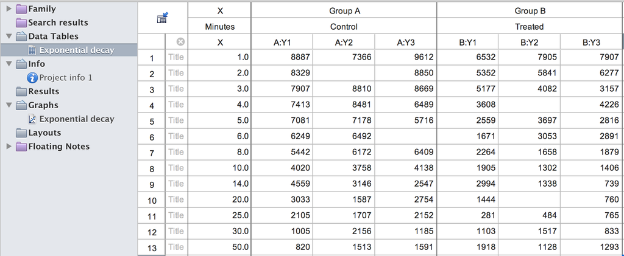

List tables from a `.pzfx` file:

```r
library(pzfx)
pzfx_tables(system.file("extdata/exponential_decay.pzfx", package="pzfx"))
```

```
#> [1] "Exponential decay"
```

Read one specific table into R by table name:

```r
df <- read_pzfx(system.file("extdata/exponential_decay.pzfx", package="pzfx"), table="Exponential decay")
head(df)
```

```
#>   Minutes Control_1 Control_2 Control_3 Treated_1 Treated_2 Treated_3
#> 1       1      8887      7366      9612      6532      7905      7907
#> 2       2      8329        NA      8850      5352      5841      6277
#> 3       3      7907      8810      8669      5177      4082      3157
#> 4       4      7413      8481      6489      3608        NA      4226
#> 5       5      7081      7178      5716      2559      3697      2816
#> 6       6      6249      6492        NA      1671      3053      2891
```

Read one specific table into R by table index (1-based):

```r
df <- read_pzfx(system.file("extdata/exponential_decay.pzfx", package="pzfx"), table=1)
head(df)
```

```
#>   Minutes Control_1 Control_2 Control_3 Treated_1 Treated_2 Treated_3
#> 1       1      8887      7366      9612      6532      7905      7907
#> 2       2      8329        NA      8850      5352      5841      6277
#> 3       3      7907      8810      8669      5177      4082      3157
#> 4       4      7413      8481      6489      3608        NA      4226
#> 5       5      7081      7178      5716      2559      3697      2816
#> 6       6      6249      6492        NA      1671      3053      2891
```

## Writing

There is a `write_pzfx` function for writing. It takes as input a data frame or a matrix, or a named list of data frames or matrices, and writes to a `.pzfx` file. To keep row names and use them as row titles in `.pzfx`, specify argument `row_names=TRUE`. To specify a column (column 1, “Col1” for example) to be used as the “X” column, specify argument `x_col=1` or `x_col="Col1"`.

```r
tmp <- tempfile(fileext=".pzfx")
write_pzfx(df, tmp, row_names=FALSE, x_col="Minutes")
out_df <- read_pzfx(tmp, table=1)
head(out_df)
```

```
#>   Minutes Control_1 Control_2 Control_3 Treated_1 Treated_2 Treated_3
#> 1       1      8887      7366      9612      6532      7905      7907
#> 2       2      8329        NA      8850      5352      5841      6277
#> 3       3      7907      8810      8669      5177      4082      3157
#> 4       4      7413      8481      6489      3608        NA      4226
#> 5       5      7081      7178      5716      2559      3697      2816
#> 6       6      6249      6492        NA      1671      3053      2891
```

```r
unlink(tmp)
```

# Additional notes

- Prism allows subcolumns. To accommodate this, `read_pzfx` automatically adds `_1`, `_2` etc to the original column name to account for sub columns if they represent replicates. It tries to infer the subcolumn types and adds appropriate suffix accordingly. For example, trailing `_MEAN`, `_SD`, `_N` are added if subcolumns represent mean, standard deviation and number of observations.
- Prism does not require columns in a table to be of the same length. To accommodate this, `NA`s are added if the columns are of different lengths.
- Prism allows user to exclude data by striking them out individual observations. To accommodate this, an option `strike_action` is available in `read_pzfx`. One can choose to delete these values with `strike_action="exclude"`, keep them with `"keep"`, or convert them to a trailing “*” (as they appear in Prism) with `"star"`. Note if `strike_action="star"` the entire table is converted to type `character`.
- Prism allows special formatting of column names such as superscripts. When reading into R, column names with special formatting are converted to regular strings.
- For writing, because R data frames and matrices don’t support hierarchical columns, the written out `.pzfx` files can only be of type “Column” or “XY”, depending on whether the “X” column is specified by `x_col`.